# Exercise 06

## 1 Bias and variance of ridge regression

$$\hat \beta = \text{arg}\underset{\beta}{\text{min}}\ \underbrace{||X\beta -y||_2^2+\tau\ ||\beta||_2^2}_{=:B}$$

We will now take the derivative of $B$ with respect to $\beta$ in order to find $\hat \beta$. $$0\overset{!}{=}\frac{\partial B}{\partial \beta}= \frac \partial{\partial \beta} \left( ||X\beta-y||^2\right)+\frac \partial{\partial \beta}\left( \tau ||\beta||^2\right) =2X^\intercal\ \left( X\beta-y\right)+2\tau \beta\\$$ $$ \Rightarrow X^\intercal y=\left(X^\intercal X+\tau \mathbb{1} \right)\beta\\ $$ $$ \Rightarrow \hat \beta = \left( X^\intercal X+\tau \mathbb{1} \right)^{-1} X^\intercal y$$ $$ \Rightarrow \hat \beta= \left( X^\intercal X+\tau \mathbb{1} \right)^{-1}\underbrace{\left(X^\intercal X\right) \left(X^\intercal X\right)^{-1}}_{\mathbb 1} X^\intercal y=\\ \left( X^\intercal X+\tau \mathbb{1} \right)^{-1} X^\intercal X \beta=S_{\tau}^{-1} S \beta $$ Now we calculate the expectation value: $$\mathbb{E}[\hat \beta]= \mathbb E [S_{\tau}^{-1}S\beta]= S_{\tau}^{-1}S\ \mathbb E [\beta] S_{\tau}^{-1}S\beta^*$$ Covariance matrix: $$ \text{Cov}\left[\hat \beta\right]=\text{Cov}\left[S_{\tau}^{-1}S\beta\right]= \left(S_{\tau}^{-1} S\right)\underbrace{\text{Cov}\left[\beta\right]}_{S^{-1} \sigma^2}\left(S_{\tau}^{-1} S\right)^\intercal= S_{\tau}^{-1} S^\intercal \left(S_{\tau}^{-1}\right)^\intercal \sigma^2= S_{\tau}^{-2} S \sigma^2 $$

<span style =" color : green ;font-weight : bold ">We did not write down where the noise $\epsilon$ went. Our expression for $\beta$ was incomlete but we did account for it in $\text{Cov}[\beta]=S^{-1}\sigma^2$</span >

## 2 Denoising of a CT image

```python
import numpy as np
import scipy.sparse as sp
import scipy.sparse.linalg as sLA
import matplotlib.pyplot as plt
%matplotlib inline
```

```python
def construct_X(M, alphas, Np = None, tau = 0):
    '''
    M: resulting tomogram size D in one dimension (D=MxM)
    alphas: list of No angles in degrees
    Np: sensor resolution (optional)
    tau: regularization parameter
    returns X of shape (Np*No)xD or (Np*No+D)xD if tau is greater than 0
    '''
    #check if tau is not negative:
    if tau<0:
        raise ValueError('tau is negative')
    #convert to numpy array and into radian
    alphas=np.array(alphas)*np.pi/180
    #in case Np is not given we will select one large enough to fit the diagonal of the image beta
    if Np==None:
        Np=np.ceil(np.sqrt(2)*M)
        if Np%2==0: #Np is even
            Np+=1

    N=len(alphas)*Np #response vector size
    D=M*M
    #create coordinate matrix C of the ceter of each pixel measured from the center of the image

    #"x" distance
    C_0 = np.mod(np.arange(D),M) - (M - 1)/2
    #"y" distance
    C_1 = np.floor_divide(np.arange(D),M) - (M - 1)/2
    #merge for C
    C = np.array([C_0,C_1]).T
    #project the C vector onto the sensor array direction
    translation = C@np.array([np.cos(alphas),np.sin(-alphas)])
    #this is now projected on the senor using the position of the center as reference
    sensorpos = (Np - 1)/ 2 + translation.T
    #first the indices of the smaller pixels then the ones of the larger ones
    i_p = np.array([np.floor(sensorpos), np.ceil(sensorpos)]).flatten()
    #[0]*D,[1]*D,...,[No-1]*D twice repeated
    i_o = np.tile(np.outer(np.arange(len(alphas)),np.ones(D)).flatten(),2)
    #combine them to our i_indices
    i_indices =  i_p + Np * i_o

    #simply [0,1,...,No-1]*2D
    j_indices = np.tile(np.tile(np.arange(D),len(alphas)),2)

    #compute the weights
    weight_ceil = np.mod(sensorpos, 1).flatten()
    weight_floor = 1 - weight_ceil
    #and combine them in the correct order
    weights = np.append(weight_floor,weight_ceil)

    #now we build the matrix X:
    X = sp.coo_matrix((weights, (i_indices, j_indices)),shape = (N,D), dtype = np.float32)
    #if tau=0 we return the X matrix...
    if tau==0:
        return X
    elif tau>0:
        #... if not we return the augmented version X'
        return sp.vstack([X,np.sqrt(tau)*sp.identity(D,format='coo')])
```

```python
def compute_mu(X,y):
    '''
    X: weight matrix of shape (N,D)
    y: sensor data
    returns the image
    '''
    #use scipy.sparse.linalg.lsqr to calculate beta, also convert X to Compressed Sparse Column format
    beta=sLA.lsqr(sp.csc_matrix(X),y,atol=1e-5,btol=1e-5)[0]
    #get M from D
    M=int(np.sqrt(len(beta)))
    #return the image mu by reshaping beta
    return beta.reshape(M,M)
```

```python
alphas = np.load('hs_tomography/alphas_195.npy')
y = np.load('hs_tomography/y_195.npy')
```

[figure not shown]

```python
fig=plt.figure(figsize=(20,30))
M,Np,No=195,275,64
#regularization parameter at each step
taus=[0, 1, 10, 100, 1000, 10000]
#64 angels:
indices=[int(np.ceil(len(alphas) * p/No)) for p in range(No)]
angels=alphas[indices]
ys=y.reshape(len(alphas),Np)[indices]
#if tau is not 0 we need to add D zeros
ytau=np.append(ys,np.zeros(M**2))

for i in range(len(taus)):
    fig.add_subplot(int(len(taus)/2),2,1+i)
    plt.gray()
    #select the correct y
    yi=ys if taus[i]==0 else ytau
    plt.imshow(compute_mu(construct_X(M,angels,Np,taus[i]),yi.flatten()))
    plt.title(r'$\tau= %i$'%(taus[i]))
    plt.axis('off')
```

out of the given $\tau$'s $\tau = 10$ and $\tau=100$ have the best compromise between the noise and the sharpness of the picture without the glowing effect that's visible for larger $\tau$'s. Maybe a better $\tau$ could be found in between the two values $10$ and $100$.

<span style =" color : green ;font-weight : bold ">The results are the same. The difference is that we displayed them in without setting the highest value to `vmax=`$255$. As a consequence the image gets brighter for large $\tau$.</span >

```python
#Now use the gaussian filter
from scipy.ndimage.filters import gaussian_filter
```

[figure not shown]

```python
fig=plt.figure(figsize=(20,30))
M,Np,No=195,275,64
#regularization parameter at each step
sig=[0,1,2,3,5,7]
#64 angels:
indices=[int(np.ceil(len(alphas) * p/No)) for p in range(No)]
angels=alphas[indices]
ys=y.reshape(len(alphas),Np)[indices]
#mu for tau=0:
Mu=compute_mu(construct_X(M,angels,Np,0),ys.flatten())
for i in range(len(sig)):
    fig.add_subplot(int(np.ceil(len(sig)/2)),2,1+i)
    plt.gray()
    #select the correct y
    yi=ys if taus[i]==0 else ytau
    plt.imshow(gaussian_filter(Mu,sig[i]))
    plt.title(r'$\sigma= %i$'%(sig[i]))
    plt.axis('off')
```

For a high sigma the picture becomes blurry. It seems like information is lost. The ridge regression on the other hand develops a glow effect but, so the overall intensity is getting higher but we still can recognize features of the patients face without problems. Both algorithms are denoising the image. The gaussian filter is better at removing the background noise but in the process the image looses sharpness.

<span style =" color : green ;font-weight : bold ">The code is equivalent with the same exception as above.</span >

## 3 Automatic feature selection for regression

```python
from sklearn.datasets import load_digits
from sklearn import model_selection
#for least squares
from sklearn import linear_model
```

### 3.1 Implement Orthogonal Matching Pursuit

```python
def omp_regression(X,y,T):
    '''
    X: ndarray with shape (N,D)
    y: ndarray with shape (N)
    T: int, desired number of non-zero elements
    returns a matrix of betas of the shape (D,T)
    '''
    #check if T > 0
    assert T>0
    #Initialization
    A = []
    B = [*range(X.shape[1])] #0...D-1
    r = y
    solutions = []
    #Iteration
    for t in range (1, T + 1):
        corr = np.abs(np.matmul(X.T, r))
        corr[A] = -1 # we are only interested in indices from B
        j = np.argmax(corr)
        A.append(B.pop(B.index(j))) #move the element j from B to A
        X_t = np.delete(X, B, axis = 1)
        reg = linear_model.LinearRegression()
        reg.fit(X_t, y)
        beta = reg.coef_
        r = y - np.matmul(X_t,beta)
        beta=np.insert(beta,(np.sort(B) - np.arange(len(B))).astype(int),0)
        beta[B] = 0
        solutions.append(beta)
        #solutions.append(beta)
    return sp.csc_matrix(np.transpose(solutions))
```

<span style =" color : green ;font-weight : bold ">It seems like the model we chose is not optimal for this probelm. We used the OLS methode described [here](https://scikit-learn.org/stable/modules/linear_model.html#ordinary-least-squares). Using the `numpy.linalg.lstsq` algorithm would have been the better choice. With that exception the code is equivalent to the solution.</span >

### 3.2 Classification with sparse LDA

```python
#load digits
digits = load_digits ()
print(digits.keys ()) #Python 3
data = digits ["data"]
images = digits ["images"]
target = digits ["target"]
target_names = digits ["target_names"]
```

```
dict_keys(['data', 'target', 'target_names', 'images', 'DESCR'])
```

```python
# filter out all 1's and 7's
X_all = data[(target==1)|(target==7)]
y_all = target[(target==1)|(target==7)]
y_all[y_all == 7] = -1 # y_i=-1 if i is a '7'

# split into train and test data
X_train, X_test, y_train , y_test = model_selection.train_test_split(X_all,y_all,test_size = 0.4,random_state = 0)
#choose randomly instances so that the trainig set is balanced (same amount of "1"'s as "7"'s)
N=sum(y_train)

instances=np.random.permutation(len(y_train[y_train==N/abs(N)]))[:abs(N)]
X_test=np.append(X_test,X_train[y_train==N/abs(N)][instances],axis=0)
X_train=np.delete(X_train,np.arange(len(y_train))[y_train==N/abs(N)][instances],axis=0)

y_test=np.append(y_test,y_train[y_train==N/abs(N)][instances],axis=0)
y_train=np.delete(y_train,np.arange(len(y_train))[y_train==N/abs(N)][instances],axis=0)
#surly not the best way to do it but it works
```

<span style =" color : green ;font-weight : bold ">The obvious difference is that we did not standarize our data. Unfortunatly we missed that part of the exercise.</span >

```python
T=40
LDAsol=omp_regression(X_train,y_train,T)
prediction=X_test@LDAsol
#split the predictions at 0
prediction[prediction<0]=-1
prediction[prediction>=0]=1
#substract y_test from each column
difference=abs(prediction-y_test[:,None])/2 #need to divide by two because the difference can only be 2
errorRate=np.mean(difference,axis=0)
var=np.var(difference,axis=0)
```

```python
for i in range(T):
    print('t=%i, Error rate: (%.2f +/- %.2f)%s'%(i+1,errorRate[i]*100,100*np.sqrt(var[i]),'%'))
```

```
t=1, Error rate: (49.14 +/- 49.99)%
t=2, Error rate: (49.14 +/- 49.99)%
t=3, Error rate: (49.14 +/- 49.99)%
t=4, Error rate: (48.57 +/- 49.98)%
t=5, Error rate: (48.00 +/- 49.96)%
t=6, Error rate: (40.57 +/- 49.10)%
t=7, Error rate: (38.86 +/- 48.74)%
t=8, Error rate: (36.00 +/- 48.00)%
t=9, Error rate: (34.86 +/- 47.65)%
t=10, Error rate: (18.86 +/- 39.12)%
t=11, Error rate: (25.71 +/- 43.71)%
t=12, Error rate: (22.86 +/- 41.99)%
t=13, Error rate: (22.86 +/- 41.99)%
t=14, Error rate: (28.57 +/- 45.18)%
t=15, Error rate: (32.00 +/- 46.65)%
t=16, Error rate: (8.57 +/- 27.99)%
t=17, Error rate: (8.57 +/- 27.99)%
t=18, Error rate: (8.57 +/- 27.99)%
t=19, Error rate: (8.57 +/- 27.99)%
t=20, Error rate: (8.57 +/- 27.99)%
t=21, Error rate: (8.57 +/- 27.99)%
t=22, Error rate: (4.00 +/- 19.60)%
t=23, Error rate: (3.43 +/- 18.20)%
t=24, Error rate: (2.86 +/- 16.66)%
t=25, Error rate: (2.29 +/- 14.94)%
t=26, Error rate: (2.29 +/- 14.94)%
t=27, Error rate: (2.29 +/- 14.94)%
t=28, Error rate: (2.86 +/- 16.66)%
t=29, Error rate: (2.29 +/- 14.94)%
t=30, Error rate: (1.71 +/- 12.98)%
t=31, Error rate: (1.14 +/- 10.63)%
t=32, Error rate: (1.14 +/- 10.63)%
t=33, Error rate: (0.57 +/- 7.54)%
t=34, Error rate: (0.57 +/- 7.54)%
t=35, Error rate: (0.57 +/- 7.54)%
t=36, Error rate: (0.57 +/- 7.54)%
t=37, Error rate: (0.00 +/- 0.00)%
t=38, Error rate: (0.00 +/- 0.00)%
t=39, Error rate: (0.00 +/- 0.00)%
t=40, Error rate: (0.00 +/- 0.00)%
```

<span style =" color : green ;font-weight : bold ">Our solution needed a significantly higher T to converge. The reason for his is our choice of the least squares algorithm. I checked it in a seperate notebook and we had the same convergence as in the solution</span >

<span style =" color : green ;font-weight : bold ">Also we failed to think of plotting the error rate.</span >

```python
featureList=np.where(LDAsol.todense().T!=0)[1] #all features contributing
featureList=featureList[np.sort(np.unique(featureList,return_index=True)[1])] #all features only once and in the correct order
```

```python
#to check if a certain pixel is in favour of class '1' we'll take the average of the training set at that pixel for all
#'1' and '7' class instances and check which value is higher.
averageDifference=np.mean(X_train[y_train==1][:,featureList],axis=0)-np.mean(X_train[y_train==-1][:,featureList],axis=0)
#divide by absolute value for only 1 and -1 as entries
averageDifference=averageDifference/abs(averageDifference)
```

```python
order=np.zeros(64)
for i in range(T):
    order[featureList[::-1][i]]=(i+1)/T*averageDifference[::-1][i]
```

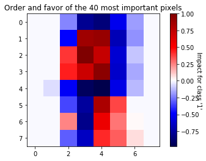

```python
plt.title('Order and favor of the %i most important pixels'%T)
plt.imshow(order.reshape((8,8)),cmap='seismic')
plt.colorbar().set_label("Impact for class '1'",rotation=270)
```

<span style =" color : green ;font-weight : bold ">The plot looks differently from the (last) one in the solution because we did not standardize the data.</span >

The darker the pixels the more important are they for the corresponing class. We can roughly a blue 7 in front of a red one. That shows that the pixels were classified correcly by the higher average.

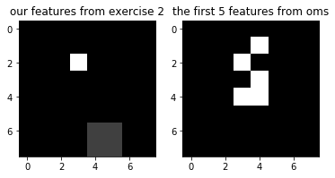

```python
plt.subplot('121')
plt.title('our features from exercise 2')
f=np.zeros((8,8))
f[2,3]=1
f[7,4]=f[7,5]=f[6,4]=f[6,5]=.25
plt.imshow(f)
plt.subplot('122')
plt.title('the first 5 features from oms')
g=np.zeros(64)
g[featureList[:5]]=1
g=g.reshape((8,8))
plt.imshow(g)
```

<span style =" color : green ;font-weight : bold ">The plots are different because we did not standardize the data and because of the other algorithm. Using the corrected version we get the same first 5 pixels as the solution.</span >

We chose one feature like the algorithm. Our other feature however used other pixels.

## 3.3 One-against-the-rest classification

```python
import pandas as pd
pd.options.display.float_format = '{:,.2f}'.format
```

```python
class classifier:
    def __init__(self,k,T):
        self.k=k
        self.T=T
    def train(self,X,y):
        y[y!=self.k]=-1
        y[y==self.k]=1
        self.beta=omp_regression(X,y,self.T).toarray().T[self.T-1]
    def predict(self,X):
        return X@self.beta
```

<span style =" color : green ;font-weight : bold ">In the `train` function we should have standardized the data. Also we forget to balance the training set here.</span >

```python
class OneAgainstTheRestClassifier:
    def __init__(self,classes,T):
        self.classes=classes
        Cs=[]
        for i in range(len(classes)):
            Cs.append(classifier(classes[i],T))
        self.C=Cs
    def train(self,X,y):
        for i in range(len(self.classes)):
            self.C[i].train(X,y.copy())
    def predict(self,X):

        def predictOneInstance(X):
            predictions=[]
            for i in range(len(self.classes)):
                predictions.append(self.C[i].predict(X))
            response=np.argmax(predictions)
            if predictions[response]<0: #biggest response is negative
                return None #class "unknown"
            else:
                return self.classes[response]

        if type(X)==np.ndarray:
            if len(X.shape)==2: #whole set
                result=[]
                #could have been vectorized but it still is reasonably fast
                for i in range(len(X)):
                    result.append(predictOneInstance(X[i]))
                return np.array(result)
            elif len(X.shape)>2:
                raise ValueError('Wrong dimensions for X')
        #only one instance to predict
        return predictOneInstance(X)
```

```python
# split into train and test data, this time with all digits
xTrain, xTest, yTrain , yTest = model_selection.train_test_split(data,target,test_size = 0.4,random_state = 0)
```

```python
oatr=OneAgainstTheRestClassifier(np.arange(10),40)
oatr.train(xTrain,yTrain)
```

<span style =" color : green ;font-weight : bold ">High T for the same reasons as above.</span >

```python
#build confusion matrix
conf=np.zeros((10,11))
data_subsets = [xTest[yTest==i] for i in  range(10)]
for i in range(10):
    # predict with OneAgainstTheRestClassifier classifier
    predictions = np.array([oatr.predict(j) for j in data_subsets[i]])
    predictions[pd.isnull(predictions)]=10
    predictions=predictions.astype(int)
    conf[i,:] = np.bincount(predictions,minlength=11)/len(data_subsets[i])*100
```

```python
matrix=pd.DataFrame(data = conf, index =range(10), columns =[*range(10),'unknown'] )
matrix.rename_axis('Actual/Predicted', axis = 'columns')
matrix
```

|  | 0 | 1 | 2 | 3 | 4 | 5 | 6 | 7 | 8 | 9 | unknown |
| --- | --- | --- | --- | --- | --- | --- | --- | --- | --- | --- | --- |
| 0 | 96.67 | 0.00 | 0.00 | 1.67 | 0.00 | 1.67 | 0.00 | 0.00 | 0.00 | 0.00 | 0.00 |
| 1 | 0.00 | 93.15 | 1.37 | 0.00 | 0.00 | 0.00 | 0.00 | 0.00 | 5.48 | 0.00 | 0.00 |
| 2 | 0.00 | 8.45 | 80.28 | 4.23 | 0.00 | 0.00 | 0.00 | 1.41 | 5.63 | 0.00 | 0.00 |
| 3 | 0.00 | 0.00 | 0.00 | 92.86 | 0.00 | 0.00 | 0.00 | 0.00 | 5.71 | 1.43 | 0.00 |
| 4 | 0.00 | 3.17 | 0.00 | 0.00 | 90.48 | 0.00 | 0.00 | 1.59 | 4.76 | 0.00 | 0.00 |
| 5 | 0.00 | 1.12 | 0.00 | 0.00 | 0.00 | 95.51 | 1.12 | 0.00 | 0.00 | 2.25 | 0.00 |
| 6 | 0.00 | 1.32 | 0.00 | 0.00 | 0.00 | 2.63 | 90.79 | 0.00 | 5.26 | 0.00 | 0.00 |
| 7 | 0.00 | 0.00 | 0.00 | 3.08 | 0.00 | 0.00 | 0.00 | 96.92 | 0.00 | 0.00 | 0.00 |
| 8 | 0.00 | 6.41 | 0.00 | 0.00 | 0.00 | 0.00 | 0.00 | 0.00 | 92.31 | 1.28 | 0.00 |
| 9 | 0.00 | 0.00 | 0.00 | 6.76 | 0.00 | 2.70 | 0.00 | 0.00 | 9.46 | 81.08 | 0.00 |

An "unknown" class is useful because if we have a corrupted test instance it is better to not take the highest value if it is still negative because that classifier did not recognize the sample as it's class and decided against it.

```python
badOatr=OneAgainstTheRestClassifier(np.arange(10),12) #small T asures many unknown instances
badOatr.train(xTrain,yTrain)
```

```python
pred=badOatr.predict(xTest)
imag=xTest[pd.isnull(pred)]
label=yTest[pd.isnull(pred)]
```

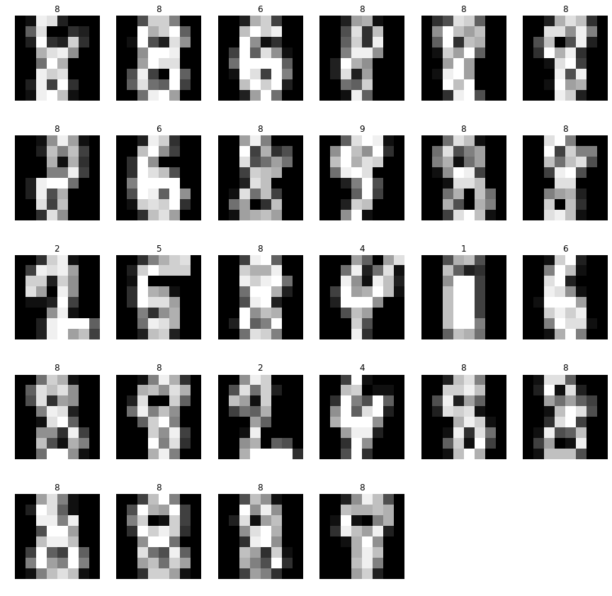

```python
plt.figure(figsize=(15,15))
for i in range(len(imag)):
    n=int(np.sqrt(len(imag)))
    plt.subplot(n,np.ceil(len(imag)/n),i+1)
    plt.axis('off')
    plt.imshow(imag[i].reshape((8,8)))
    plt.title(label[i])
```

As we can see most of the "unknown" images represent a $8$. That is because the digit $8$ the most pixels from the whole set to be displayed. For a small $T$ we are limiting the amount of pixels hence the classification of the digit $8$ becomes harder. The rest of the digits are hard to read even when you know what digit it is supposed to display.